# Mass 211: Decision Trees

This report surveys two popular tree-based additive regression algorithms–Random Forests and Gradient Boosting–and evaluate their performance in predicting the 2-1-1 demands.

## Methods

Calls related to Call2Talk and Suicide Prevention Hotline are excluded since they are more vulnerable to skewness caused by repetitive calls.

```r
setwd('~/Dropbox/Work/Mass 211')
if (!exists('mcalls.full')) {
  source('src/utils/helpers.R')
  source('src/utils/geo.R')
  mcalls.full <- read_csv('data/mcalls_full.csv')
}
dat <- mcalls.full %>%
  filter(
    # Remove "Mental Health Hotlines"
    # and "Suicide Prevention Hotlines"
    # cat.code != 'RP-1500.1400-500',
    # cat.code != 'RP-1500.1400-800',
    date >= ymd('2016-06-01'),
    date < ymd('2017-09-01')
  ) %>%
  DistinctCalls() %>%
  GeoCount("zip", TRUE) %>%
  filter(
    TotalPop > 100,
    n_call >= 5
  ) %>%
  mutate(
    # PopDensity = log(pop_den),
    calls_n = n_call,
    calls = log(n_call * 1000 / TotalPop)
    # calls = log(n_call * 1000 / TotalPop),
    # name = NULL,
    # n_call = NULL,
    # total_pop = NULL
    # total_land = NULL,
    # total_urban_land = NULL
  ) %>%
  select(
    -name,
    -starts_with('n_call'),
    -starts_with('p_call'),
    -ends_with('_land'),
    # -contains('p.urban'),
    -urban_popden,
    -HSGrad,
    -SomeColl,
    -Bach, -Master, -Prof, -Doc,
    # -BelowPovertyMarried,
    # -BelowPovertyOccupied,
    # -pop_den,
    -total_pop
  )
dat <- dat %>%
  na.omit() %>%
  as.data.frame()
dat_int <- dat %>%
  select(-calls)
dat <- dat %>%
  select(
    -calls_n, -TotalPop
  )
write_csv(dat, 'data/aci_zip_calls.csv')  # ACI with calls by ZIP code
```

```r
## Check Point
setwd('~/Dropbox/Work/Mass 211')
if (!exists('dat')) {
   dat <- read_csv('data/mcalls_full.csv')
}
```

## Random Forest

Random forests repetitively sample a subset of variables and observations to build a tree, then averages the node values to find the best variable/value for splitting the trees.

By smoothing over different trees, Random Forests is resilient to overfitting. It is robust to an increase of noise variables, and generally performs better with many noise variables than other bagging models such as Gradient Boosting.

That been said, we still have a few hyperparameters to tune: the size of sample observations used during each iteration, the number of variables to draw, the number of trees to grow (# of iterations), and the minimal/maximal size of terminal nodes (size of the trees).

### Number of randomly selected splitting variables m

Among these parameters, perhaps the most imporatant one is the number of random variables (predictors) selected when growing a tree. Following plot shows the Out of Bag Error (for training data) and Test Error (for validation data) for different number of variables selected.

```r
set.seed(1984)
# use 70% data for training and remaining 30% for validation
train <- sample(1:nrow(dat), ceiling(nrow(dat) * 0.7))
dat.train <- dat[train, ]
dat.test <- dat[-train, ]
y <- dat$calls
x <- dat %>% select(-calls)
# removed mostly-zero variables and strongly correlated variables
x2 <- x[, -nearZeroVar(x)]
x2 <- x2[, -findCorrelation(cor(x2), .9)]
x2 <- as.data.frame(x2)
# scaled
x2.scaled <- scale(x2)
oob.err <- double(1)
oob.err.full <- double(1)
test.err <- double(1)
#mtry is no of Variables randomly chosen at each split
for(mtry in 1:65) {
  rf.train <- randomForest(
    calls ~ ., data = dat.train, mtry = mtry, ntree = 500
  )
  rf.full <- randomForest(
    calls ~ ., data = dat, mtry = mtry, ntree = 500
  )
  oob.err[mtry] <- rf.train$mse[500] #Error of all Trees fitted
  oob.err.full[mtry] <- rf.full$mse[500]

  pred <- predict(rf.train, dat.test) #Predictions on Test Set for each Tree
  test.err[mtry] <- with(dat.test, mean((calls - pred) ^ 2)) # Mean Squared Test Error
  # cat(mtry, " ") #printing the output to the console
}
```

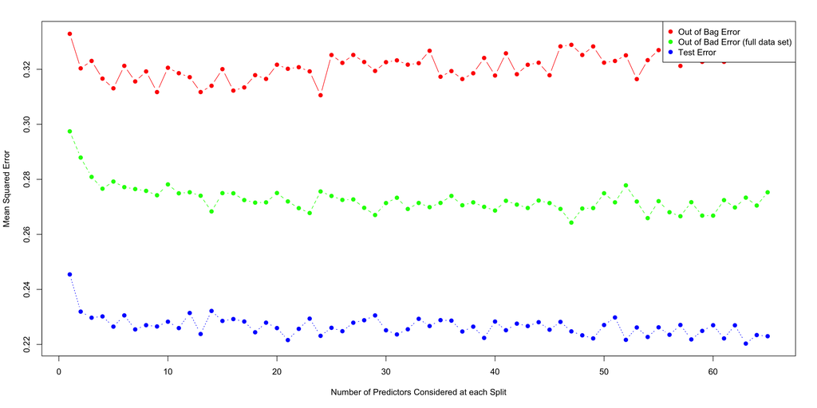

```r
matplot(
  1:mtry ,
  cbind(oob.err, oob.err.full, test.err),
  pch = 19 ,
  col = c("red", "green", "blue"),
  type = "b",
  ylab = "Mean Squared Error",
  xlab = "Number of Predictors Considered at each Split"
)
legend(
  "topright",
  legend = c("Out of Bag Error",
             "Out of Bad Error (full data set)",
             "Test Error"),
  pch = 19,
  col = c("red", "green", "blue")
)
```

The `randomForest` package actually provides a function `turnRF` for the same purpose.

```
mtry = 2  OOB error = 0.2797281
Searching left ...
Searching right ...
mtry = 3    OOB error = 0.2744315
0.0189346 0.001
mtry = 4    OOB error = 0.2705102
0.01428874 0.001
mtry = 6    OOB error = 0.2695209
0.003657343 0.001
mtry = 9    OOB error = 0.269326
0.0007229654 0.001

Call:
 randomForest(x = x, y = y, mtry = res[which.min(res[, 2]), 1])
               Type of random forest: regression
                     Number of trees: 500
No. of variables tried at each split: 9

          Mean of squared residuals: 0.2710415
                    % Var explained: 61.72
```

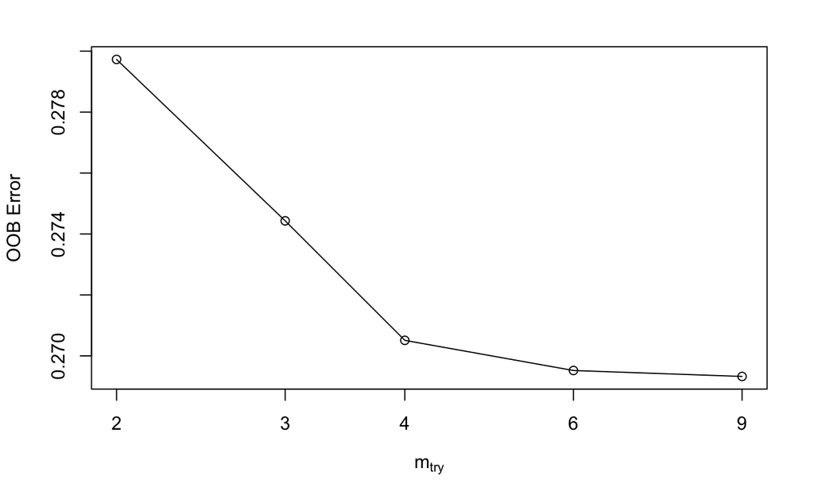

```r
tuneRF(x, y, mtryStart = 2, ntreeTry = 500, stepFactor=1.5, improve=0.001, doBest=TRUE)
```

### Minimal/Maximal node size

The minimal and maximal node size defines the depth of the tree. [The Elemenets of Statistical Learning](https://web.stanford.edu/~hastie/ElemStatLearn/) recommends let the tree grow to its maximal, because it seldom make much difference in terms of speed and performance.

The minimal node size may have an effect, but the impact is different depending on the dataset.

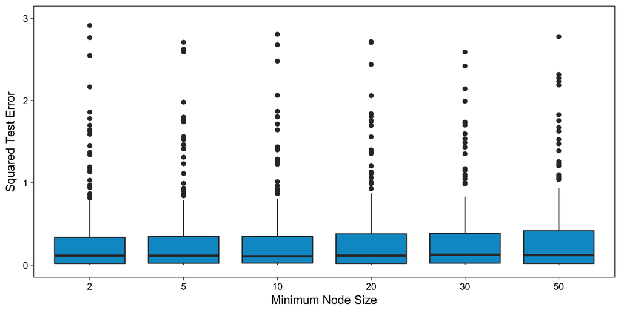

Above graph shows the squared test error in regards to different minimum node sizes. The larger the node size, the shallower the tree is. It is clear that minimum node size doesn’t matter in our case, neither.

### Variable Importance

One of the most useful application of Random Forest is to find variable importance. It can be evaluated by the increase in MSE when values of a variable are shuffled (%IncMSE), or the increase in node purities after using a variable for splitting the trees (IncNodePurity). We often only consider the former metric while evaluating the variables.

```r
set.seed(1984)
model <- randomForest(calls ~ .,
                      data = dat,
                      # na.action = na.roughfix,
                      # subset = train,
                      ntree = 400,
                      mtry = 10,
                      importance = TRUE)
model
```

```
Call:
 randomForest(formula = calls ~ ., data = dat, ntree = 400, mtry = 10,      importance = TRUE)
               Type of random forest: regression
                     Number of trees: 400
No. of variables tried at each split: 10

          Mean of squared residuals: 0.2820046
                    % Var explained: 60.83
```

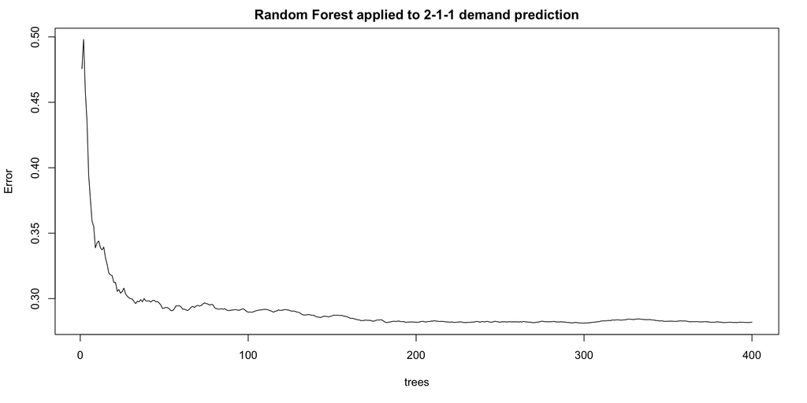

```r
plot(model, main="Random Forest applied to 2-1-1 demand prediction")
```

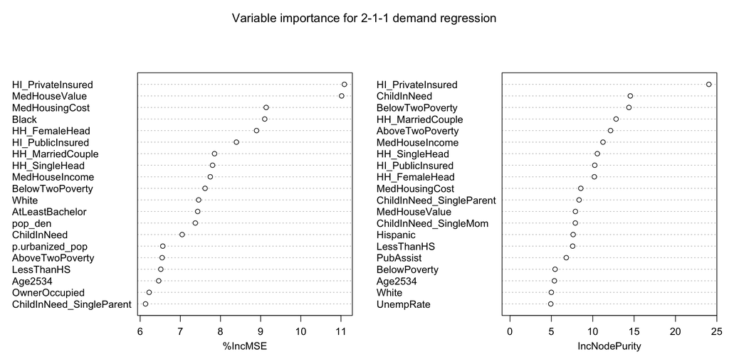

```r
varImpPlot(model, main="Variable importance for 2-1-1 demand regression", n.var=20)
```

Surprisingly, the proportion of people who have private health insurance turns out to be the most important variable.

Possible explanations for the top variables are:

#### HI_PrivateInsured

This is an indicator for “quality employment”. People with private health insurance mostly get their health insurances from employer as an employment benefit. Employment with health care benefits tend to be those high-paying permanent jobs. Therefore high-paying jobs is a reflection of many other factors–such as good education, rich neighborhood, being of specific race, etc.

#### MedHouseValue

Median value of the property. This variable indicates how “rich” a neighborhood is. This seems to be, according to the model, a better indicator than the actual income of people who live in the neighborhood. One explantion is that some people with low income and high demand in services live in places with relatively high property values, too—namely, poor people who rent and live in the inner city.

#### MedHouseIncome

This one is straightforward.

#### ChildInNeed

Percentage of children living in a household that is receiving income support.

#### MedHousingCost

Median monthly housing cost, including morgages and gross rent. This variable also bears a sense of urbanity in it.

In addition to above two variables, we have also MedRentAsIncomePct—the median value of rent as percentage of house income. Surprisingly, this variable didn’t even make it to the Top 30.

#### Black

THe proportion of the residents being black. It is not a surprise that race is a huge factor in shaping the landscape of service needs.

#### Age2534

Age group 23 to 34 year old. Young parents are more likely to use one of the major services 2-1-1 provides: tracking the status of their application for child care assistance.

#### HH_MarriedCouple

Household type: married couple. Families with married couples are more stable and more resilient to financial difficulties.

#### AtLeastBachelor

Percentage of people with at least a 4-year Barchelor’s degree for population 25 years and over. Education has implications in income and social stigma of using public services.

## Comapre with Linear Regression

For comparison, using a Linear Regression model and Backwards Selection with bootstrap resampling, we identifies the Top 5 variables as: `White`, `Hispanic`, `Black`, `OwnerOccupied`, and `MedHouseValue`.

```r
rfe_sizes <- c(2, 4, 8, 10, 13, 15, 20, 25, 30, 40)
ctrl <- rfeControl(functions = lmFuncs,
                   # resampling methods: bootstrap
                   method = "boot",
                   number = 200,
                   verbose = FALSE)
ctrl2 <- rfeControl(functions = lmFuncs,
                   # resampling methods: bootstrap
                   method = "boot",
                   rerank = TRUE,
                   number = 200,
                   verbose = FALSE)
# must use scaled values for linear regressions
lmProfile <- rfe(x2.scaled, y, sizes = rfe_sizes, rfeControl = ctrl)
lmProfile2 <- rfe(x2.scaled, y, sizes = rfe_sizes, rfeControl = ctrl2)
min(count.zip$p_call)
```

```
[1] 0
```

```r
lmProfile
```

```
Recursive feature selection

Outer resampling method: Bootstrapped (200 reps)

Resampling performance over subset size:

 Variables   RMSE Rsquared    MAE  RMSESD RsquaredSD   MAESD Selected
         2 0.6649   0.3862 0.5230 0.06098    0.11308 0.05331
         4 0.6006   0.5000 0.4633 0.05152    0.08827 0.04130
         8 0.5578   0.5713 0.4263 0.04331    0.06522 0.02953
        10 0.5480   0.5878 0.4196 0.04524    0.06109 0.02685
        13 0.5427   0.5972 0.4167 0.04509    0.06235 0.02743
        15 0.5411   0.6005 0.4155 0.04313    0.06081 0.02613        *
        20 0.5465   0.5957 0.4201 0.04195    0.05988 0.02630
        25 0.5529   0.5890 0.4259 0.03915    0.05619 0.02555
        30 0.5589   0.5829 0.4306 0.03888    0.05527 0.02513
        40 0.5655   0.5762 0.4352 0.04073    0.05756 0.02575
        53 0.5664   0.5753 0.4358 0.04098    0.05809 0.02560

The top 5 variables (out of 15):
   White, Hispanic, Black, MedHouseValue, OwnerOccupied
```

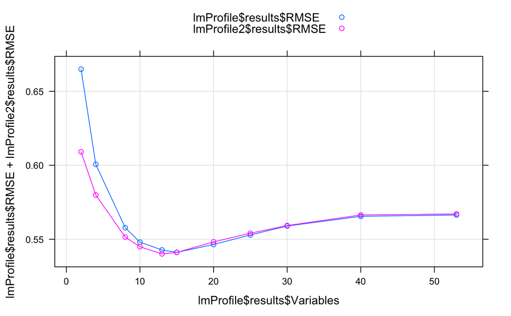

```r
xyplot(lmProfile$results$RMSE + lmProfile2$results$RMSE  ~
       lmProfile$results$Variables,
       type = c("g", "p", "l"),
       auto.key = TRUE)
```

Race seems to be the most prominent factor, but it actually didn’t turn to be conclusive in the best fitted model.

```r
summary(lmProfile2$fit)
```

```
Call:
lm(formula = y ~ ., data = tmp)

Residuals:
     Min       1Q   Median       3Q      Max
-1.67604 -0.30509 -0.00574  0.34366  1.75039

Coefficients:
                 Estimate Std. Error t value Pr(>|t|)
(Intercept)       1.52212    0.02441  62.361  < 2e-16 ***
White            -0.69037    0.26964  -2.560 0.010816 *
Hispanic         -0.35719    0.16920  -2.111 0.035373 *
MedHouseValue    -0.27776    0.04891  -5.679 2.58e-08 ***
Black            -0.12892    0.12311  -1.047 0.295644
OwnerOccupied    -0.32902    0.07222  -4.556 6.90e-06 ***
AtLeastBachelor  -0.18440    0.06884  -2.679 0.007691 **
Asian            -0.16352    0.09650  -1.695 0.090914 .
HH_SingleHead     0.27398    0.07488   3.659 0.000286 ***
HH_LiveAlone      0.29791    0.07234   4.118 4.63e-05 ***
HH_MarriedCouple  0.30072    0.10915   2.755 0.006132 **
BornInState      -0.01644    0.04978  -0.330 0.741379
Age6064           0.15138    0.02811   5.386 1.22e-07 ***
LessThanHS       -0.18674    0.06081  -3.071 0.002276 **
---
Signif. codes:  0 ‘***’ 0.001 ‘**’ 0.01 ‘*’ 0.05 ‘.’ 0.1 ‘ ’ 1

Residual standard error: 0.5008 on 407 degrees of freedom
Multiple R-squared:  0.6634,    Adjusted R-squared:  0.6526
F-statistic: 61.69 on 13 and 407 DF,  p-value: < 2.2e-16
```

```r
summary(update(lmProfile2$fit, data=dat,
               formula = log_p_call ~ . + HI_PrivateInsured))
```

```
Call:
lm(formula = log_p_call ~ White + Hispanic + MedHouseValue +
    Black + OwnerOccupied + AtLeastBachelor + Asian + HH_SingleHead +
    HH_LiveAlone + HH_MarriedCouple + BornInState + Age6064 +
    LessThanHS + HI_PrivateInsured, data = dat)

Residuals:
     Min       1Q   Median       3Q      Max
-2.64419 -0.30374  0.01231  0.38671  2.62336

Coefficients:
                    Estimate Std. Error t value Pr(>|t|)
(Intercept)        7.294e+00  1.595e+00   4.574 6.11e-06 ***
White             -2.249e+00  1.500e+00  -1.499 0.134458
Hispanic          -1.288e+00  1.509e+00  -0.853 0.393998
MedHouseValue     -1.405e-03  2.626e-04  -5.350 1.37e-07 ***
Black             -4.194e-02  1.618e+00  -0.026 0.979334
OwnerOccupied     -9.001e-01  3.693e-01  -2.437 0.015175 *
AtLeastBachelor   -1.504e+00  4.046e-01  -3.717 0.000226 ***
Asian             -4.092e-01  1.681e+00  -0.243 0.807785
HH_SingleHead      1.365e+00  1.020e+00   1.339 0.181372
HH_LiveAlone       2.390e+00  8.626e-01   2.771 0.005815 **
HH_MarriedCouple   5.499e-01  8.157e-01   0.674 0.500587
BornInState        3.980e-01  3.836e-01   1.037 0.300077
Age6064           -6.974e+02  5.774e+02  -1.208 0.227714
LessThanHS        -2.832e+00  9.113e-01  -3.107 0.002001 **
HI_PrivateInsured -7.139e-01  5.558e-01  -1.284 0.199630
---
Signif. codes:  0 ‘***’ 0.001 ‘**’ 0.01 ‘*’ 0.05 ‘.’ 0.1 ‘ ’ 1

Residual standard error: 0.6206 on 473 degrees of freedom
  (7 observations deleted due to missingness)
Multiple R-squared:  0.5775,    Adjusted R-squared:  0.565
F-statistic: 46.19 on 14 and 473 DF,  p-value: < 2.2e-16
```

```r
summary(lmProfile2$fit)
```

[output not shown]

## Partial Plot

Partial dependence plot shows the marginal effect of a variable on the class response, i.e., the effect of adding another variable to a model of existing variables. We apply this plotting technique with our Random Forest model.

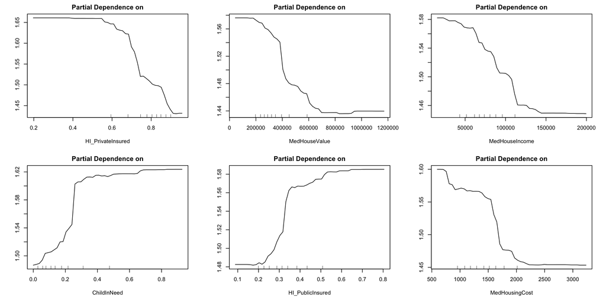

```r
imp <- importance(model)
# %IncMSE, i.e., decrease in accuracy if exclude this variable
impvar <- rownames(imp)[order(imp[, 1], decreasing=TRUE)][1:12]
op <- par(mfrow=c(2, 3))
for (i in seq_along(impvar)) {
    partialPlot(model, dat, impvar[i], xlab=impvar[i],
                main=paste("Partial Dependence on"))
}
```

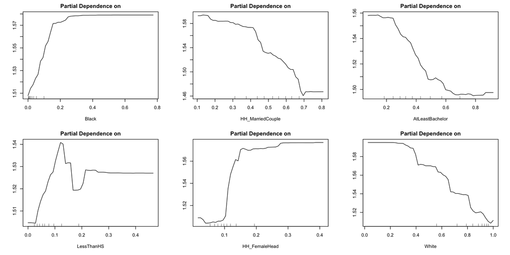

```r
par(op)
```

We shall see a steady linear relationship if a variable is very important. The ticks at the base of the plots are deciles of the x variables, so we can infer the distribution of the x variables, too. The direction of the lines explains whether a variable is positively or negatively correlated with the target variable.

The shape of the lines also bears some implications. For example, the plateau in the line of `MedHousingCost` (monthly housing cost), in the range between 1,000 USD to 1,500 USD per month, implies that a neighborhood’s probability of in high demand of human services decreases sharply once its median rent reached above 1,500 per month. The same can be said for `HI_PublicInsured` and `ChildInNeed`, if the proportion of people who relies on Medicaid or other public health insurance options for their health care needs is more than 30%, or more than 20% of the children live in a family that requires income assistance, then the demand for 2-1-1 services increases dramatically.

## Gradient Boosting

Another popular technique in additive learning is Gradient Boosting. It creates a set of weaker learners and additively use information derived from existing models to improve the choices made for latter models.

We apply Gradient Boosting to the same variables we trained above.

```r
dat_p <- dat %>%
  rename(calls = p_call) %>%
  select(
    -name,
    -town,
    -county,
    -pa_name,
    -shape_area,
    -log_p_call,
    -starts_with('n_call'),
    -starts_with('p_call'),
    -ends_with('_land'),
    # -contains('p.urban'),
    -urban_popden,
    -HSGrad,
    -SomeColl,
    -Bach, -Master, -Prof, -Doc,
    # -BelowPovertyMarried,
    # -BelowPovertyOccupied,
    # -pop_den,
    -total_pop
  )
```

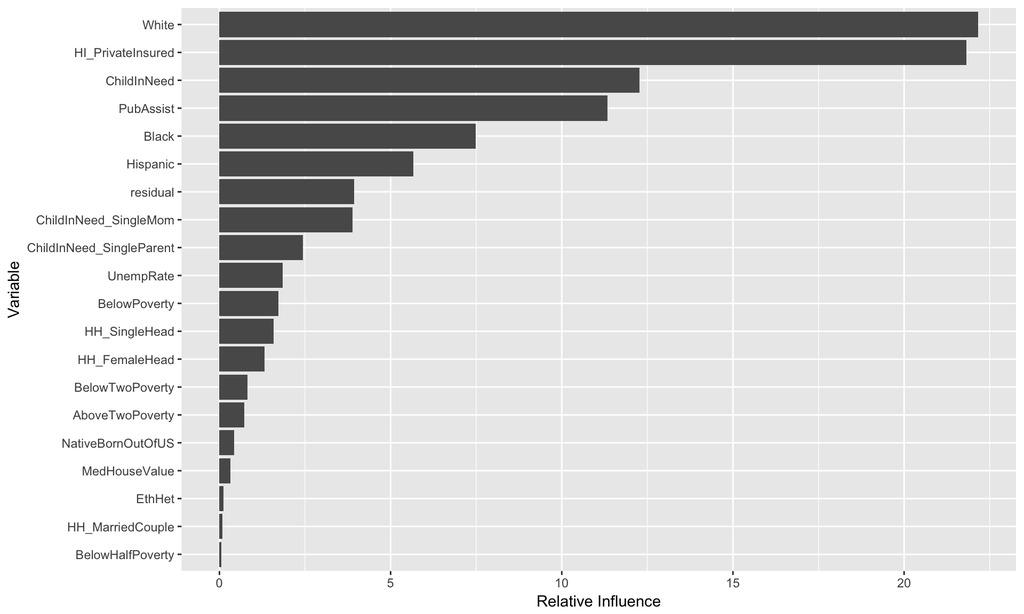

```r
gmb1 <- gbm(calls ~ .,
            n.tree = 1000,
            interaction.depth = 1,
            distribution = 'gaussian',
            data = dat_p)
# relative influence of variables
relInf <- summary(gmb1, plot_it = FALSE)
relInf %>% head(20) %>%
  ggplot(aes(x = fct_reorder(var, rel_inf), y=rel_inf)) +
  geom_col() +
  coord_flip() +
  labs(x = 'Variable', y = 'Relative Influence')
```

### Poisson regression with GBM

The `gbm` function from the `gbm3` package allows us to specify the distribution of the response variable. Since the number of calls can be considered as count data, we may apply Poisson distribution here as well.

We use the raw number of calls per ZIP code, together with an offset variable–log total population.

```r
dat_int <- dat %>%
  select(
    -name,
    -town,
    -county,
    -pa_name,
    -shape_area,
    -log_p_call,
    -starts_with('n_call_'),
    -starts_with('p_call'),
    -ends_with('_land'),
    # -contains('p.urban'),
    -urban_popden,
    -HSGrad,
    -SomeColl,
    -Bach, -Master, -Prof, -Doc,
    # -BelowPovertyMarried,
    # -BelowPovertyOccupied,
    # -pop_den,
    -total_pop
  )
```

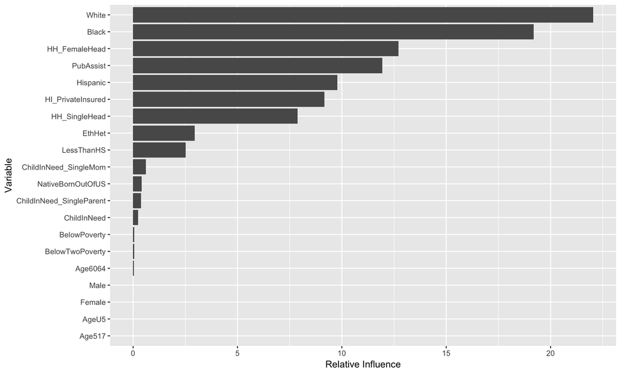

```r
# Poisson distribution, offset by log population
gmb2 <- gbm(n_call ~ offset(log(TotalPop)) + . -TotalPop,
            n.tree = 1000,
            interaction.depth = 1,
            distribution = 'poisson',
            data = dat_int)
# relative influence of variables
relInf <- summary(gmb2, plot_it = FALSE)
relInf %>% head(20) %>%
  ggplot(aes(x = fct_reorder(var, rel_inf), y=rel_inf)) +
  geom_col() +
  coord_flip() +
  labs(x = 'Variable', y = 'Relative Influence')
```

This time race is identified as the most influencial factor again, but insurance status and the proportion of single moms (`HH_FemaleHead` and `HH_SingleHead`) also remained important.

## Next Step

Currently all above analyses are based on the full data we have. Samples and test are just splitting ZIP codes into groups. Another way of evaluating models is sampling call records and generate two copies of aggregated metrics for all ZIP codes, on different samples of calls, of course. The sampling process can be completely random, or based on time—i.e., train the model with old data and evaluate the model with the most recent data.